# Neural Networks Diabetes

Roberto Baca

15/08/2025

# Diabetes Prediction Using Neural Networks

## Introduction

The PimaIndiansDiabetes dataset (from the mlbench package) contains medical data from Pima Indian women aged 21 and older, collected by the National Institute of Diabetes and Digestive and Kidney Diseases.

**The goal is to predict whether a patient has diabetes based on certain clinical measurements.**.

The dataset includes 768 records and 9 columns:

- pregnant: number of pregnancies
- glucose: plasma glucose concentration during a tolerance test
- pressure: diastolic blood pressure (mm Hg)
- triceps: triceps skinfold thickness (mm)
- insulin: 2-hour serum insulin level (µU/ml)
- mass: body mass index (BMI)
- pedigree: genetic probability (diabetes pedigree function)
- age: age (years)
- diabetes: target variable, with values “pos” (positive) or “neg” (negative)

An **economic analysis** will also be performed, assuming a simplified scenario:

- The cost of a False Negative (a person with diabetes who is NOT diagnosed) is high, as it poses serious health risks. We assume a cost of USD 1,000 per False Negative (medical expenses, complications, etc.).
- The cost of a False Positive (a healthy person incorrectly diagnosed with diabetes) is lower but not negligible. We assume a cost of USD 100 per False Positive (medical visits, additional tests, etc.).

From the confusion matrix, we can calculate:

- FN = False Negatives
- FP = False Positives

## Loading Libraries and Dataset

```r
# libraries
library(nnet)
library(caret)
library(neuralnet)
library(pROC)
library(ggplot2)
library(tidyverse)
```

```r
# dataset
library(mlbench)
data("PimaIndiansDiabetes2")
df <- PimaIndiansDiabetes2

str(df)
```

```
## 'data.frame':    768 obs. of  9 variables:
##  $ pregnant: num  6 1 8 1 0 5 3 10 2 8 ...
##  $ glucose : num  148 85 183 89 137 116 78 115 197 125 ...
##  $ pressure: num  72 66 64 66 40 74 50 NA 70 96 ...
##  $ triceps : num  35 29 NA 23 35 NA 32 NA 45 NA ...
##  $ insulin : num  NA NA NA 94 168 NA 88 NA 543 NA ...
##  $ mass    : num  33.6 26.6 23.3 28.1 43.1 25.6 31 35.3 30.5 NA ...
##  $ pedigree: num  0.627 0.351 0.672 0.167 2.288 ...
##  $ age     : num  50 31 32 21 33 30 26 29 53 54 ...
##  $ diabetes: Factor w/ 2 levels "neg","pos": 2 1 2 1 2 1 2 1 2 2 ...
```

```r
# drop na
df<- na.omit(df)
summary(df)
```

```
##     pregnant         glucose         pressure         triceps
##  Min.   : 0.000   Min.   : 56.0   Min.   : 24.00   Min.   : 7.00
##  1st Qu.: 1.000   1st Qu.: 99.0   1st Qu.: 62.00   1st Qu.:21.00
##  Median : 2.000   Median :119.0   Median : 70.00   Median :29.00
##  Mean   : 3.301   Mean   :122.6   Mean   : 70.66   Mean   :29.15
##  3rd Qu.: 5.000   3rd Qu.:143.0   3rd Qu.: 78.00   3rd Qu.:37.00
##  Max.   :17.000   Max.   :198.0   Max.   :110.00   Max.   :63.00
##     insulin            mass          pedigree           age        diabetes
##  Min.   : 14.00   Min.   :18.20   Min.   :0.0850   Min.   :21.00   neg:262
##  1st Qu.: 76.75   1st Qu.:28.40   1st Qu.:0.2697   1st Qu.:23.00   pos:130
##  Median :125.50   Median :33.20   Median :0.4495   Median :27.00
##  Mean   :156.06   Mean   :33.09   Mean   :0.5230   Mean   :30.86
##  3rd Qu.:190.00   3rd Qu.:37.10   3rd Qu.:0.6870   3rd Qu.:36.00
##  Max.   :846.00   Max.   :67.10   Max.   :2.4200   Max.   :81.00
```

```r
# Keep the original labels and fix the order: "pos" first
df$diabetes <- factor(df$diabetes, levels = c("pos", "neg"))
prop.table(table(df$diabetes))
```

```
##
##       pos       neg
## 0.3316327 0.6683673
```

## Train-Test Split

```r
# split
set.seed(123)
train_index <- createDataPartition(df$diabetes, p=0.7, list=FALSE)
train <- df[train_index, ]
test  <- df[-train_index, ]

y_test  <- test$diabetes
```

## Class Balancing with ROSE

Since the dataset is imbalanced, we will apply the ROSE method.

ROSE (Random OverSampling Examples) is a technique that generates synthetic examples to balance the dataset. Instead of cloning existing data, it creates new and diverse samples.

```r
# Apply ROSE to the training set for balancing

#install.packages("ROSE")
library(ROSE)

mayoritarios <- sum(train$diabetes == "neg")

train_rose <- ROSE(diabetes ~ ., data=train, N = 2 * mayoritarios, seed=123)$data

table(train_rose$diabetes)
```

```
##
## neg pos
## 193 175
```

## Feature Scaling

Important: scaling is performed using the training set parameters to avoid data leakage from the test set.

```r
# scale the balanced training set
preProc <- preProcess(train_rose[ ,-9], method = c("center", "scale"))
train_rose_sc <- predict(preProc, train_rose %>% select(-diabetes))
train_rose_sc$diabetes <- train_rose$diabetes

# scale the test set using the same training set parameters
test_sc <- predict(preProc, test %>% select(-diabetes))
test_sc$diabetes <- test$diabetes

str(test_sc)
```

```
## 'data.frame':    117 obs. of  9 variables:
##  $ pregnant: num  -0.8937 -0.0796 0.463 -0.0796 2.0911 ...
##  $ glucose : num  0.186 -1.455 0.992 -0.12 0.353 ...
##  $ pressure: num  -2.1169 -1.4664 -0.0353 1.0056 1.3959 ...
##  $ triceps : num  0.427 0.175 -0.917 0.932 0.259 ...
##  $ insulin : num  -0.0363 -0.5511 0.00874 0.39484 -0.17787 ...
##  $ mass    : num  1.009 -0.34 -0.92 0.585 0.284 ...
##  $ pedigree: num  4.676 -0.689 0.202 0.51 -0.673 ...
##  $ age     : num  0.00732 -0.55075 1.44237 -0.47103 1.44237 ...
##  $ diabetes: Factor w/ 2 levels "pos","neg": 1 1 1 2 1 1 1 2 2 2 ...
##  - attr(*, "na.action")= 'omit' Named int [1:376] 1 2 3 6 8 10 11 12 13 16 ...
##   ..- attr(*, "names")= chr [1:376] "1" "2" "3" "6" ...
```

# Modeling

## 1. Simple Neural Network without hyperparameter tuning

```r
set.seed(123)

nn_simple <- nnet(diabetes ~ ., data = train_rose_sc, size = 4, decay = 0.01, maxit = 200, trace=FALSE)

# Predictions as the probability of the positive class ("pos")
pred_simple <- predict(nn_simple, test_sc, type = "raw")

# Convert to class labels using a 0.5 threshold (pos/neg)
pred_simple_clase <- factor(ifelse(pred_simple >= 0.5, "pos", "neg"), levels = levels(test_sc$diabetes))

conf_simple <- confusionMatrix(pred_simple_clase, test_sc$diabetes,positive = "pos")
conf_simple
```

```
## Confusion Matrix and Statistics
##
##           Reference
## Prediction pos neg
##        pos  26  15
##        neg  13  63
##
##                Accuracy : 0.7607
##                  95% CI : (0.673, 0.8347)
##     No Information Rate : 0.6667
##     P-Value [Acc > NIR] : 0.01775
##
##                   Kappa : 0.4684
##
##  Mcnemar's Test P-Value : 0.85011
##
##             Sensitivity : 0.6667
##             Specificity : 0.8077
##          Pos Pred Value : 0.6341
##          Neg Pred Value : 0.8289
##              Prevalence : 0.3333
##          Detection Rate : 0.2222
##    Detection Prevalence : 0.3504
##       Balanced Accuracy : 0.7372
##
##        'Positive' Class : pos
##
```

```r
library(knitr)

fn_simple <- conf_simple$table[2,1]
fp_simple <- conf_simple$table[1,2]
cost_simple <- fn_simple * 1000 + fp_simple *100

# Economic Analysis of Simple Neural Network
# Create a data frame with the results
resumen_modelos <- data.frame(
  Model = c("Simple Neural Network"),
  FN = c(fn_simple),
  FP = c(fp_simple),
  Cost_USD = c(cost_simple)
)

kable(resumen_modelos, caption = "Simple Neural Network – Estimated Costs")
```

Simple Neural Network – Estimated Costs

| Model | FN | FP | Cost_USD |
| --- | --- | --- | --- |
| Simple Neural Network | 13 | 15 | 14500 |

## Variable Importance

We can assess the importance of variables in the neural network using nnet models:

- olden() → strength + sign of contribution
- garson() → normalized relative importance, magnitude only

**Olden** shows the strength and sign of each input variable’s contribution to the model’s prediction. Each bar indicates whether a variable has a positive or negative effect on the probability of the output being “pos”. This helps understand how each feature directly affects the network’s decision.

**Garson** calculates the relative importance of each variable, normalized between 0 and 1. It does not indicate the sign, only how influential each input is for the prediction. It is useful for identifying the most relevant variables regardless of the direction of their effect.

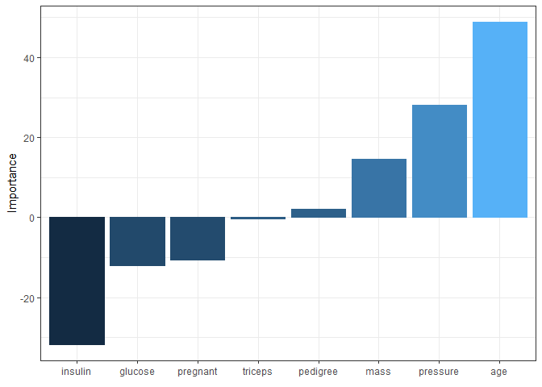

```r
# install.packages("NeuralNetTools")
library(NeuralNetTools)

# Strength and Sign of Inputs
olden(nn_simple, bar_plot = TRUE)
```

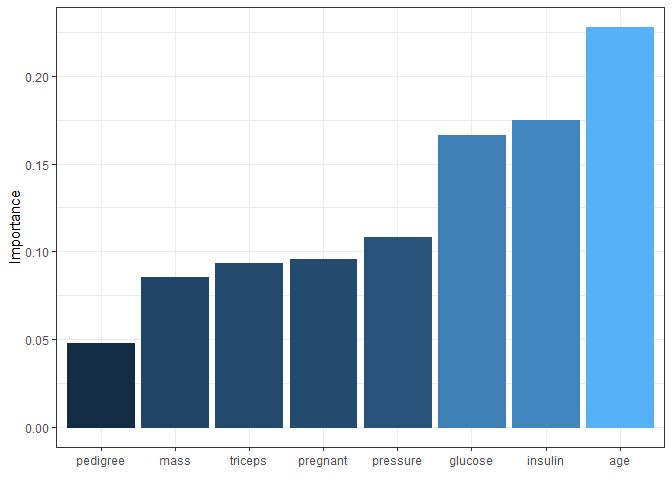

```r
# Relative Importance of Variables
garson(nn_simple, bar_plot = TRUE)
```

## 2. Neural Network with Hyperparameter Tuning

For the neural network with hyperparameters, a grid search combined with 5-fold cross-validation was applied, optimizing the ROC metric to select the best combination of neurons and regularization.

In cross-validation, the data is split into multiple parts to repeatedly train and validate the model, aiming to find a stable and generalizable solution.

```r
# cross-validation
ctrl <- trainControl(
  method = "cv",
  number = 5,
  classProbs = TRUE,
  summaryFunction = twoClassSummary,
  savePredictions = "final"
)

# Hyperparameter Grid
grid <- expand.grid(
  size  = c(3, 5, 7),           # Neurons in the single hidden layer of the nnet model
  decay = c(0.001, 0.01, 0.1)   # Regularization
)
```

```r
set.seed(123)

nn_hiper <- caret::train(diabetes ~ .,
                     data = train_rose_sc,
                     method = "nnet",
                     metric = "ROC",
                     trControl = ctrl, # control
                     tuneGrid = grid, # Hyperparameters
                     MaxNWts = 2000, # Maximum Number of Weights
                     maxit = 300, # Maximum Iterations
                     trace = FALSE # Sigmoid Activation

)
```

```r
# Predictions as the probability of the positive class ("pos")
pred_hiper_prob <- predict(nn_hiper, newdata = test_sc, type = "prob")[, "pos"]

# Convert to class labels using a 0.5 threshold
pred_hiper_clase <- factor(ifelse(pred_hiper_prob >= 0.5, "pos", "neg"),levels = levels(test_sc$diabetes))

conf_hiper <- confusionMatrix(pred_hiper_clase, test_sc$diabetes, positive = "pos")
conf_hiper
```

```
## Confusion Matrix and Statistics
##
##           Reference
## Prediction pos neg
##        pos  24  17
##        neg  15  61
##
##                Accuracy : 0.7265
##                  95% CI : (0.6364, 0.8048)
##     No Information Rate : 0.6667
##     P-Value [Acc > NIR] : 0.09981
##
##                   Kappa : 0.3924
##
##  Mcnemar's Test P-Value : 0.85968
##
##             Sensitivity : 0.6154
##             Specificity : 0.7821
##          Pos Pred Value : 0.5854
##          Neg Pred Value : 0.8026
##              Prevalence : 0.3333
##          Detection Rate : 0.2051
##    Detection Prevalence : 0.3504
##       Balanced Accuracy : 0.6987
##
##        'Positive' Class : pos
##
```

```r
library(knitr)
fn_hiper <- conf_hiper$table[2,1]
fp_hiper <- conf_hiper$table[1,2]
cost_hiper <- fn_hiper * 1000 + fp_hiper *100

resumen_hiper <- data.frame(
  Model = "Neural Network with Hyperparameters",
  FN = fn_hiper,
  FP = fp_hiper,
  Cost_USD = cost_hiper
)


kable(resumen_hiper, caption = "Neural Network with Hyperparameters – Estimated Costs")
```

Neural Network with Hyperparameters – Estimated Costs

| Model | FN | FP | Cost_USD |
| --- | --- | --- | --- |
| Neural Network with Hyperparameters | 15 | 17 | 16700 |

# 3. Multilayer Perceptron (MLP) with neuralnet

The multilayer perceptron (MLP) with neuralnet is a neural network with multiple hidden layers trained directly on the scaled data, where the number of neurons per layer is specified manually, and a sigmoid function is used for the output.

```r
#install.packages("neuralnet")
library(neuralnet)

# Convert diabetes to numeric 0/1
train_nn <- train_rose_sc
train_nn$diabetes <- ifelse(train_nn$diabetes == "pos", 1, 0)

test_nn <- test_sc
test_nn$diabetes <- ifelse(test_nn$diabetes == "pos", 1, 0)

# Create a dynamic formula
form <- as.formula("diabetes ~ .")

# Train the network with multiple hidden layers (5 and 3 neurons)
set.seed(123)

modelo_nn <- neuralnet(
  formula = form,
  data = train_nn,
  hidden = c(4,2), # Two hidden layers
  linear.output = FALSE, # Sigmoid output
  lifesign = "minimal", # Reduce console output
  threshold = 0.01,
  stepmax = 1e6 # Maximum number of steps
)
```

```
## hidden: 4, 2    thresh: 0.01    rep: 1/1    steps:   29424   error: 13.37224 time: 7.81 secs
```

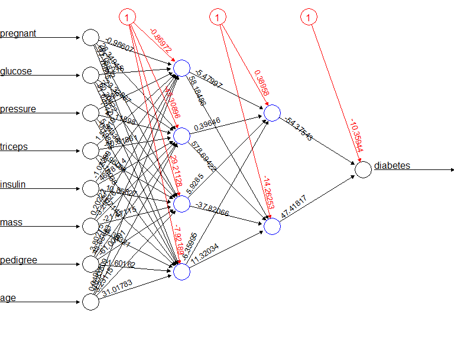

```r
plot(modelo_nn,
           rep="best",         # Better node layout
           show.weights=TRUE,  # Display connection weights
           show.values=TRUE,   # Display neuron values
           col.hidden="blue",
           col.hidden.synapse="black",
           col.intercept="red",
           information=FALSE   # Avoid extra text
           )
```

The plot generated by plot(modelo_nn) in neuralnet shows the structure of the trained neural network:

- Nodes (circles): represent the neurons in each layer.
- The first layer corresponds to the inputs (features).
- The intermediate layers are the hidden layers.
- The last layer is the output (diabetes prediction 0/1).
- Connections (lines): represent the synaptic weights between neurons.
- Nodes with a value of 1 in the plot are dummy nodes, representing the bias of the neurons in the network. This bias allows the neuron to activate even if all inputs are 0, or to adjust its activation threshold. It is essential for the network to learn correctly.

**This plot allows us to visualize how each input contributes to the output through the hidden layers and how the weights are distributed in the network**

```r
# Predictions
pred_nn <- neuralnet::compute(modelo_nn, test_nn[, -9])$net.result
pred_clases <- ifelse(pred_nn > 0.5, 1, 0)

# Confusion Matrix
conf_neural <- confusionMatrix(
  factor(pred_clases, levels = c(0,1)),
  factor(test_nn$diabetes, levels = c(0,1)),
  positive = "1"
)
conf_neural
```

```
## Confusion Matrix and Statistics
##
##           Reference
## Prediction  0  1
##          0 64 14
##          1 14 25
##
##                Accuracy : 0.7607
##                  95% CI : (0.673, 0.8347)
##     No Information Rate : 0.6667
##     P-Value [Acc > NIR] : 0.01775
##
##                   Kappa : 0.4615
##
##  Mcnemar's Test P-Value : 1.00000
##
##             Sensitivity : 0.6410
##             Specificity : 0.8205
##          Pos Pred Value : 0.6410
##          Neg Pred Value : 0.8205
##              Prevalence : 0.3333
##          Detection Rate : 0.2137
##    Detection Prevalence : 0.3333
##       Balanced Accuracy : 0.7308
##
##        'Positive' Class : 1
##
```

```r
# Economic Analysis of Multilayer Perceptron (MLP)
fn_multi <- conf_neural$table[2,1]
fp_multi <- conf_neural$table[1,2]
cost_multi <- fn_multi * 1000 + fp_multi *100

# reate a data frame for the MLP results
resumen_multi <- data.frame(
  Model = "Multilayer Perceptron (MLP)",
  FN = fn_multi,
  FP = fp_multi,
  Cost_USD = cost_multi
)

# Mostrar tabla
kable(resumen_multi, caption = "Multilayer Neural Network – Estimated Costs")
```

Multilayer Neural Network – Estimated Costs

| Model | FN | FP | Cost_USD |
| --- | --- | --- | --- |
| Multilayer Perceptron (MLP) | 14 | 14 | 15400 |

## ROC Curves

The ROC curve (Receiver Operating Characteristic) represents the relationship between the true positive rate (sensitivity) and the false positive rate (1 − specificity) across different classification thresholds. It allows evaluating a model’s ability to correctly distinguish between positive and negative classes, regardless of a specific threshold.

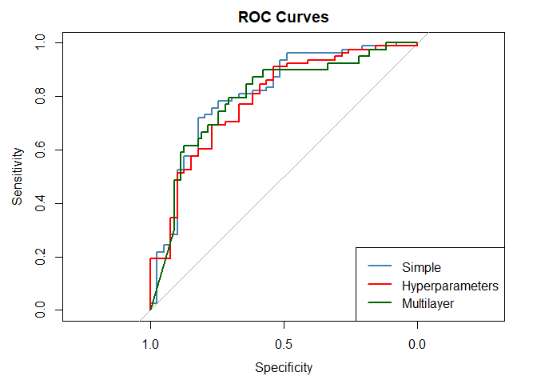

```r
# ROC Curves
roc_simple <- roc(y_test, as.vector(pred_simple))
roc_hiper  <- roc(y_test, as.vector(pred_hiper_prob))
roc_multi <- roc(test_nn$diabetes, as.vector(pred_nn))


# Plot ROC Curves Together
plot(roc_simple, col="steelblue", main="ROC Curves", lwd=2)
lines(roc_hiper, col="red", lwd=2)
lines(roc_multi, col="darkgreen", lwd=2)
legend("bottomright", legend=c("Simple","Hyperparameters","Multilayer"),
       col=c("steelblue","red","darkgreen"), lwd=2)
```

## AUC

The Area Under the Curve (AUC) summarizes the model’s discriminative ability:

- 0.5 → model has no discriminative power (random).
- 1.0 → perfect model.

```r
library(pROC)

# Calculate AUC and 95% CI for each model
auc_simple <- auc(roc_simple)
ci_simple <- ci.auc(roc_simple)

auc_hiper <- auc(roc_hiper)
ci_hiper <- ci.auc(roc_hiper)

auc_multi <- auc(roc_multi)
ci_multi <- ci.auc(roc_multi)

# Create a data frame
tabla_auc <- data.frame(
  Model = c("Simple", "Hyperparameters", "Multilayer"),
  AUC = c(auc_simple, auc_hiper, auc_multi),
  CI_Lower = c(ci_simple[1], ci_hiper[1], ci_multi[1]),
  CI_Upper = c(ci_simple[3], ci_hiper[3], ci_multi[3])
)

# table
kable(tabla_auc, digits = 3, caption = "AUC and Confidence Interval per Model")
```

AUC and Confidence Interval per Model

| Model | AUC | CI_Lower | CI_Upper |
| --- | --- | --- | --- |
| Simple | 0.807 | 0.718 | 0.896 |
| Hyperparameters | 0.786 | 0.697 | 0.875 |
| Multilayer | 0.792 | 0.703 | 0.881 |

The confidence intervals (95% CI) demonstrate statistical robustness, as they do not include 0.5, confirming that all models perform significantly better than a random classifier.

## Economic Comparison

```r
# Create a data frame with the results of each model
comparacion_modelos <- data.frame(
  Model = c("Simple", "Hyperparameters", "Multilayer"),
  FN = c(fn_simple, fn_hiper, fn_multi),
  FP = c(fp_simple, fp_hiper, fp_multi),
  Cost_USD = c(cost_simple, cost_hiper, cost_multi),
  Sensitivity = c(conf_simple$byClass["Sensitivity"],
                   conf_hiper$byClass["Sensitivity"],
                   conf_neural$byClass["Sensitivity"]),
  Specificity = c(conf_simple$byClass["Specificity"],
                    conf_hiper$byClass["Specificity"],
                    conf_neural$byClass["Specificity"]),
  Accuracy = c(conf_simple$overall["Accuracy"],
               conf_hiper$overall["Accuracy"],
               conf_neural$overall["Accuracy"]),
  stringsAsFactors = FALSE
)

# Calculate AUC
library(pROC)
roc_simple <- roc(y_test, as.vector(pred_simple))
roc_hiper  <- roc(y_test, as.vector(pred_hiper_prob))
roc_multi  <- roc(y_test, as.vector(pred_nn))

comparacion_modelos$AUC <- c(auc(roc_simple), auc(roc_hiper), auc(roc_multi))

# table
kable(comparacion_modelos)
```

| Model | FN | FP | Cost_USD | Sensitivity | Specificity | Accuracy | AUC |
| --- | --- | --- | --- | --- | --- | --- | --- |
| Simple | 13 | 15 | 14500 | 0.6666667 | 0.8076923 | 0.7606838 | 0.8067061 |
| Hyperparameters | 15 | 17 | 16700 | 0.6153846 | 0.7820513 | 0.7264957 | 0.7859961 |
| Multilayer | 14 | 14 | 15400 | 0.6410256 | 0.8205128 | 0.7606838 | 0.7919132 |

# Conclusions

From a medical and economic perspective, the Simple Neural Network is the most balanced option, as it has the lowest number of false negatives (better protecting patients with diabetes) and the lowest total cost. Additionally, it demonstrates good sensitivity and AUC.